# Instrumentation

Marc Nicollerat

# 9 Messen von elektrischen Größen

- Spannungsmessungen
- Strommessungen
- Einige besondere Eigenschaften, die es zu beachten gilt:
  - Messung von kontinuierlichen Größen
  - Messung von Wechselstrom, sinusförmigen oder einfach periodischen Größen
  - Messung von Hochspannung, großen Strömen
  - Messung von schwachen Signalen

## 9.1 Spannungsmessung: Analoges Multimeter

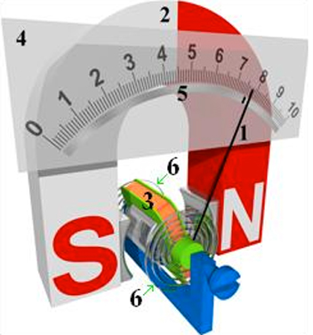

- Funktioniert wie ein Motor mit einer Feder :
  - $T_m=I \cdot K_i$ Motordrehmoment
  - $T_r=\alpha \cdot K_r$ Drehmoment der Feder
  - Mit $T_m=T_r$ erhält man eine Beziehung zwischen Strom und Winkel: $I=\alpha \cdot \frac{ K_r}{K_i}$
- Der Widerstand der Wicklung oder externe Widerstände bestimmen den Strom $U=R\cdot I$.
- Man kann den Widerstand $R$ variieren, um den Messbereich zu ändern.

**Tip**

Ein Strommesser funktioniert auf die gleiche Weise, indem er einen sehr kleinen, aber sehr genauen Widerstand verwendet (*ein Shunt*).

**Übung**

- Wie misst man eine Wechselspannung mit einem solchen analogen Multimeter?
- Berechnen Sie den Wert eines externen Widerstands, um den Messbereich zu verzehnfachen ($R_{mult}=10k\Omega, V_{max}=10V$).

## 9.2 Spannungsmessung: Lasteffekt

Typische Impedanz: Fluke 289 Multimeter

- Messung der Spannung : $10 M\Omega$
- Strommessung 10 A: $0.04 \Omega$
- Strommessung 400mA : $1.8\Omega$

**Übungen**

- Der verbrauchte Strom impliziert einen Einfluss auf die Schaltung.
  - Berechnen Sie den verbrauchten Strom bei einer gegebenen Spannung (240V).
  - Berechnen Sie den Spannungsabfall eines Amperemeters bei einer gegebenen Stromstärke (10A,400mA).

[figure not shown]

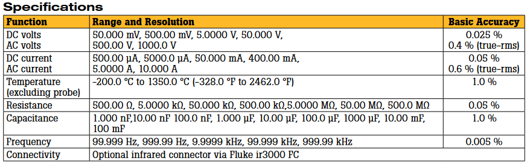

## 9.3 Digitalmultimeter

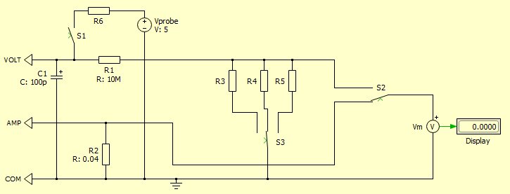

Schema eines Digitalmultimeters

| Abschwächer | R1 + R3/R4/R5 | S3 wählt den Bereich aus |
| --- | --- | --- |
| Selektoren | S2 | Messtyp |
|  | S1 | Impedanzmessung |
| Shunt | R2 | für Strommessung, je nach Bereich unterschiedlicher Shunt |
| Impedanzmessung | Vprobe, R6 | Einspeisung einer Messspannung |
| Niederspannungsmessung | Vm1 | Präzisions-A/D-Wandler, ein Mikrocontroller sorgt für die Anzeige unter Berücksichtigung des Modus |

## 9.4 Messungen mit Oszilloskop

- **Die Masse ist mit der Erde verbunden**.
- Kategorien von Oszilloskop-Tastköpfen
  - 10x, Standard, 10Mohms / 20pF
  - 100x, Hochspannungsmessung
  - aktiver Tastkopf, sehr niedrige Impedanz, 6GHz, 1 pF
  - Aktiver differentieller Tastkopf, sehr schnelle Signalmessung (Uhren, Datenbus).

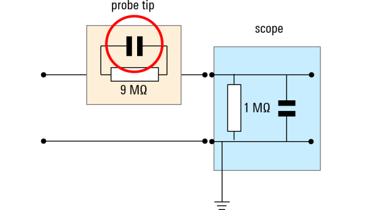

Prinzipschaltbild einer 10x Sonde. Man muss den Kondensator einstellen, damit die Sonde richtig reagiert

- Differenzialspannungssonde, Hochspannungsmessung
- Stromsonde (Hall-Effekt)

## 9.5 Messung von Wechselgrößen: Varianten

Es gibt 2 Varianten der Wechselspannungsmessung:

1. Gleichrichten und den linearen Mittelwert messen, dann die Amplitude mit einer Korrektur anpassen

**Übung**

- Berechnen Sie die Korrektur, die notwendig ist, damit das Voltmeter den Effektivwert eines sinusförmigen Signals anzeigt.
- Welchen Fehler hat man, wenn das gemessene Signal rechteckig ist?
2. Digitalisiere das hochfrequente Signal und berechne den **True RMS**-Wert.

**Übung**

- Zeichnen Sie das Blockschaltbild der Signalverarbeitung.
- Welche Hauptmerkmale sind zu berücksichtigen?

## 9.6 Spannungstastköpfe

Eigenschaften der Spannungssonde :

- Die Eingangsimpedanz des Messgeräts erhöhen.
- Elektromagnetische Störungen der Messung reduzieren.
- Den Messbereich vergrößern
- Eine galvanische Trennung durchführen ( aber das ist nicht immer der Fall )

Realisierung: resistive oder kapazitive Teiler oder beides

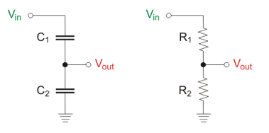

Schema der Sonde

$$\begin{array}a
V_{out}=\frac{C1}{C1+C2} V_{in} \\
V_{out}=\frac{R2}{R1+R2} V_{in}
\end{array}$$

**Übungen**

- Berechnen Sie $R1$ und $C1$ einer Oszilloskopsonde x10, wenn $R2 = 10MΩ$ und. $C2 = 20pF$
- Skizzieren Sie die Form von $V_{out}$, wenn $V_{in}$ ein rechteckiges Signal ist und $R1$ (a) zu klein, (b) zu groß ist.

## 9.7 Galvanische Trennung

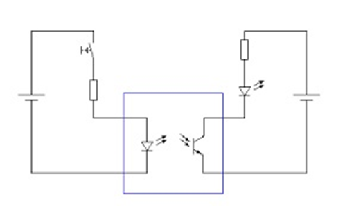

Prinzip der optischen Isolierung

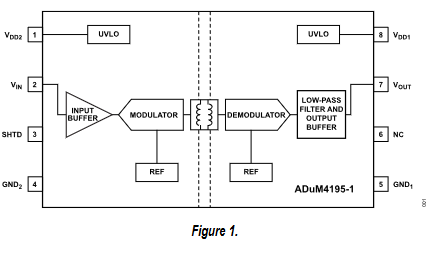

Chip mit induktiver galvanischer Trennung

[figure not shown]

Messung von Hochspannung (4200 VRMS) mit einem Produkt von LEM. Die Spannung wird an einen Widerstand angelegt, das Modul misst den Strom

[figure not shown]

Ein Spannungswandler dient dazu, eine galvanische Trennung zu erreichen

## 9.8 Hochspannungsmessung

Messung mit kapazitivem Teiler in der Durchführungsklemme.

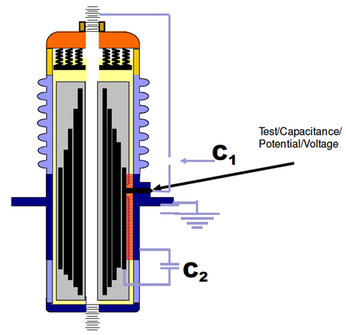

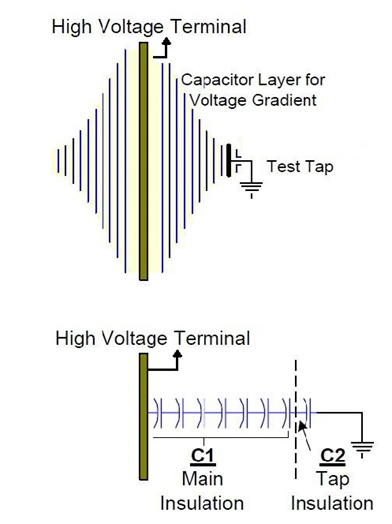

## 9.9 Hochspannungsmessung und Strommessung mit Transformator

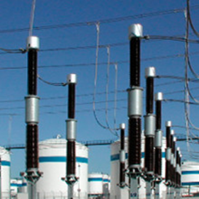

Spannungswandler

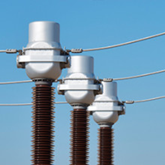

Stromtransformator

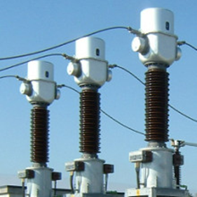

Kombinierter Transformator

Figure 1: Verschiedene Systeme zur Messung von Hochspannung.

## 9.10 Stromtransformator

Der *TI* ist ein *Stromwandler*. Er funktioniert wie ein Transformator.

Die Last hat eine niedrige Impedanz = Der Transformator arbeitet im Kurzschluss, man misst einen Bruchteil des Hauptstroms auf der Sekundärseite.

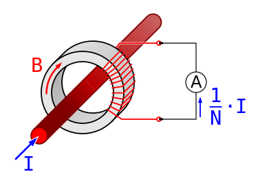

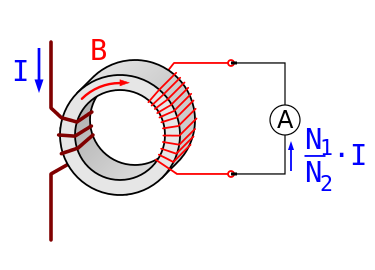

[figure not shown]

- Man darf die Sekundärseite eines TI niemals offen lassen.
- Man kann ein TI nicht zur Messung eines Gleichstroms verwenden.

## 9.11 Messen von elektrischen Strömen

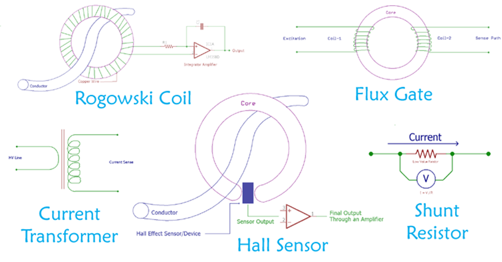

Verschiedene Arten der Strommessung

## 9.12 Rogowski-Spule

Stromwandler ohne Magnetkern: flexibel, linear, sehr schnelle Signalmessung.

Die Ausgangsspannung ist proportional zur Ableitung des Stroms (Faradaysches Gesetz $e=- \frac{d\Phi}{dt}$).

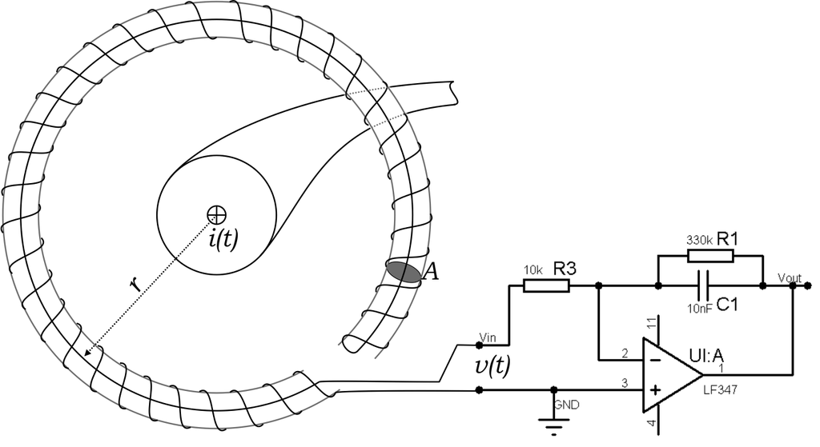

[figure not shown]

Figure 2: Rogowski-Sonde

## 9.13 Stromsensor mit Hallsonde

Der Hall-Sensor nutzt das Lorentz-Gesetz aus.
$$\overrightarrow F = q \overrightarrow E + q \overrightarrow v \land \overrightarrow B$$
Der Sensor arbeitet durch Kompensation des Magnetfeldes, wodurch er sehr linear ist.

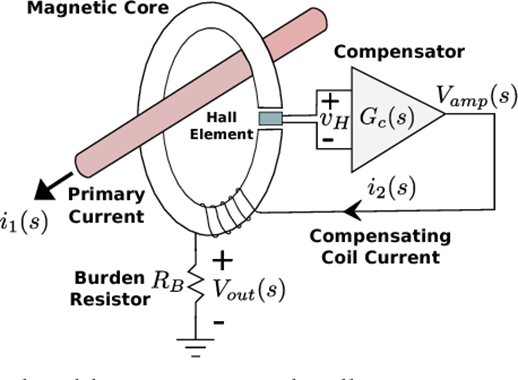

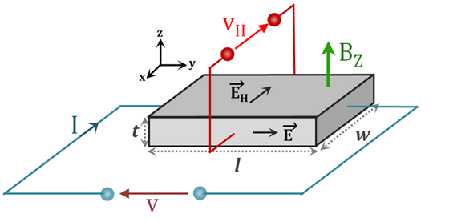

Hall-Sonden-Prinzip

[figure not shown]

Beispiel für einen LEM-Sensor

## 9.14 Flux Gate

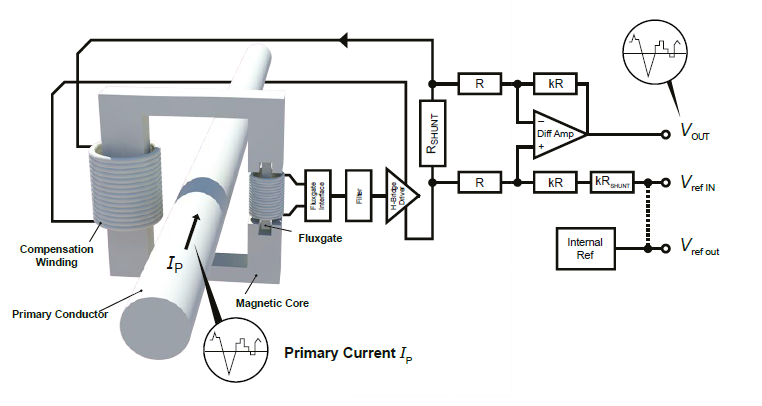

Die Primärerregung bringt den Kern periodisch in die Sättigung. Der durch den zu messenden Strom erzeugte Fluss addiert sich zum Erregungssignal und bringt das gemessene Signal aus dem Gleichgewicht.

Ein Stromsensor arbeitet wie der Hall-Sensor nach dem Prinzip der Kompensation.

- Es können auch Gleichströme gemessen werden.
- Die Empfindlichkeit ist besser als bei einer Hallsonde.

## 9.15 Differenzialschutzschalter

Der Fehlerstromschutzschalter (FI-Schalter) wird als Sicherheitseinrichtung in elektrischen Anlagen verwendet.

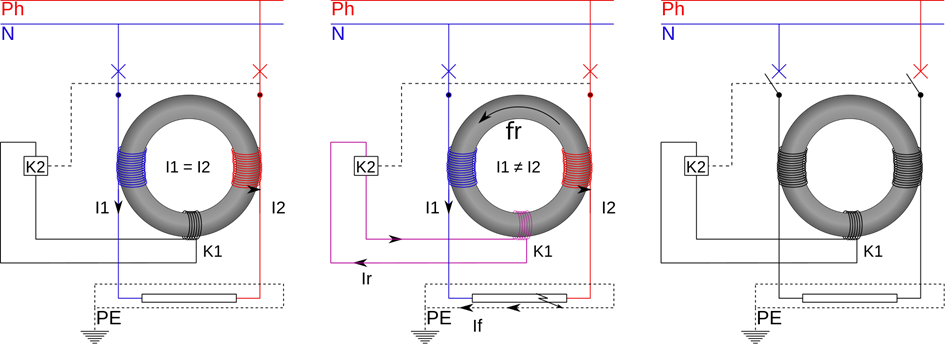

Wenn die Ströme I1 und I2 aufgrund eines Ableitstroms If unterschiedlich sind, bewirkt das Relais K2, dass die Stromversorgung unterbrochen wird. Das Relais K2 bleibt in diesem Zustand bis zur nächsten Rückstellung, die nur möglich ist, wenn der Fehlerstrom If verschwunden ist.

Quelle: Wikipedia

## 9.16 Messung von Wechselgrößen: Problem

Bei einer alternativen Größe interessiert man sich für einen *Durchschnittswert* über einen Zeitraum.

Man definiert die *effektive* Spannung oder den *effektiven* Strom: äquivalente Gleichspannung, um die gleiche Leistung wie bei einer Wechselspannung zu erhalten.

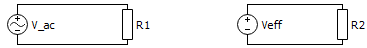

Äquivalenz zwischen der von der Wechselspannung übertragenen Leistung und einer äquivalenten Gleichspannung

$$\begin{align}
p(t)=u_{AC}(t)\cdot i(t) &= \frac{u_{AC}^2(t)}{R} \\
P_{AC} &= \frac{1}{T}\int_0^T{\frac{u_{AC}(t)^2}{R} dt} \\
P_{AC} &= \frac{U_{eff}^2}{R}
\end{align}$$

**Übung**

- Wie lautet der Ausdruck von $U_{eff}$ als Funktion von $u_{AC}(t)$?
- Wenn $u_{AC}(t)=U_{peak}\cdot \sin(2\pi f t)$, wie ist das Verhältnis von $U_{eff}$ zu $U_{peak}$?

## 9.17 Leistung von alternativen Systemen

Ausdruck für die momentane Leistung

$$p(t)=u(t) \cdot i(t)$$

Definition der RMS-Leistung

- Wenn man eine Wechselspannung hat (50-Hz-Netz), wird die durchschnittliche Leistung über eine Periode des Netzes betrachtet.
- Man berechnet die RMS-Spannungen und -Ströme wie folgt:
  $$\begin{align}
  U_{eff}=\sqrt{\frac{1}{T}\int_0^T{u^2(t)dt}} &&
  I_{eff}=\sqrt{\frac{1}{T}\int_0^T{i^2(t)dt}}
  \end{align}$$

## 9.18 Wirk- und Blindleistung

Simulation eines RL-Schaltkreises

**Note**

PLECS-Simulation durchsuchbar… Beispiel mit dem jupyter notebook dev_9.2_transcient_analysis.

- Die momentane Leistung berechnen.
- Über einen Zeitraum integrieren, um die Energie zu erhalten.
- Den Wert von L variieren
- Den Wert von R variieren

**Übung**

- Beobachten Sie die Beziehung zwischen Strom und Spannung an einem Kondensator und dann an einer Induktivität.

**Tip**

- Eine Induktivität oder ein Kondensator verbrauchen keine Energie.
- Man unterscheidet zwischen *Wirkleistung* und *Blindleistung*.

## 9.19 Darstellung in komplexen Zahlen

Man kann Spannungen und Ströme sowie passive Komponenten durch komplexe Zahlen darstellen und so Wirk- und Blindleistung berechnen.

$$\underline{S} = \underline{U} \cdot \underline{I^*} = P + jQ$$

Wir definieren die folgenden Begriffe:

- $P$ ist die Wirkleistung (Realteil).
- $Q$ ist die Blindleistung (Imaginärteil).
- $\left|{\underline{S}}\right|$ ist die Scheinleistung

Man definiert *drehende Phasen* nach dem Modell :
$$\underline X= \hat X \cdot e^{j\omega t}, \quad \textrm{avec} \quad X=U,I,P$$

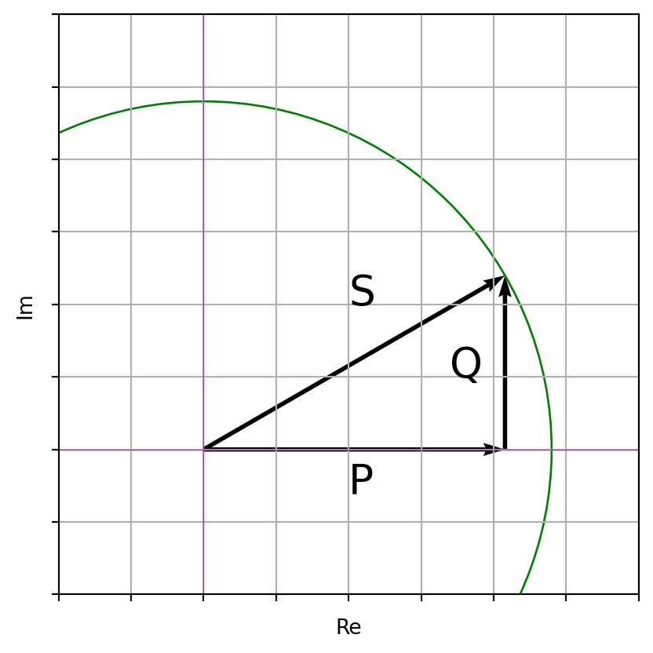

Figure 3: Représentation dans le plan complexe

Der Winkel $\varphi$ zwischen der Spannung und dem Strom ist die Phasenverschiebung. Die Größe $\cos \varphi$ wird oft gemessen, um die Qualität eines Verbrauchers zu beurteilen. Die ideale $\cos \phi$ ist 1, ohne Blindleistung.

## 9.20 Messung von Leistung und Phasenverschiebung

Die Leistung P und die Wirkleistung werden wie folgt berechnet:

$$P={\frac{1}{T}}\int\limits_{t=0}^T{p(t) \, dt}, \quad S=U\cdot I$$

Die Blindleistung $Q$ folgt aus der Beziehung

$$Q=\sqrt{S^2-P^2}$$

Man kann die Phasenverschiebung berechnen
$$\phi=tan^{-1}\left(\frac{Q}{P}\right)$$

Dies ist nur dann korrekt, wenn es keine *harmonische Verzerrung* gibt.

## 9.21 Messung durch digitale Verarbeitung

Die Messung erfolgt in der Regel durch eine *digitale Verarbeitung*.

- Die Messung erfolgt auf der Grundlage der *Frequenz* der gemessenen Größen.
- Die Signale werden *abgetastet* mit einer Frequenz, die ein Vielfaches der Grundfrequenz der Signale beträgt.

Entweder
$$u[k], i[k], k=1..N$$
kann man die Effektivgrößen berechnen
$$\begin{array}a
U_{eff}=\frac{1}{\sqrt{2}N}\sqrt{\sum_{k=1}^N{u^2[k]}}
&&
I_{eff}=\frac{1}{\sqrt{2}N}\sqrt{\sum_{k=1}^N{i^2[k]}}
\\
P_{act}=\frac{1}{N}\sum_{k=1}^N{u[k]\cdot i[k]}
\end{array}$$

## 9.22 Simulation von RL- und RC-Schaltungen

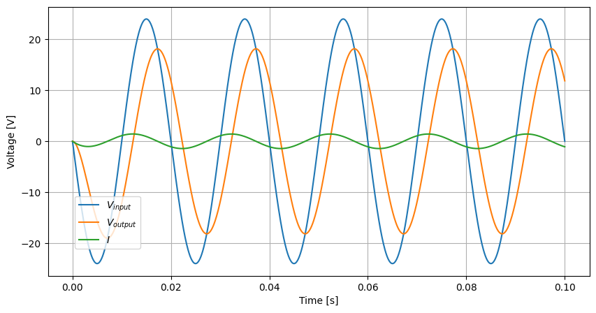

RC-Schaltung

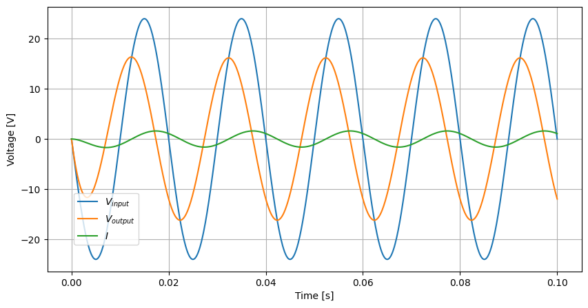

RL-Schaltung

## 9.23 Übertragene elektrische Energie

Energie erhält man ganz allgemein durch Integration der Leistung während einer Zeitspanne.
$$E(d) = \int\limits_{t=0}^{d} P(t) \, dt$$

Bei periodischen Signalen ist es sinnvoll, über Vielfache der Periode zu integrieren $T$, wobei davon ausgegangen wird, dass $P_k$ während der Periode k konstant ist.

$$k = n \cdot T, n \quad entier$$

**Tip**

In der Praxis ist es akzeptabel anzunehmen, dass während einer Periode des Stromnetzes (T = 20msec) die übertragene Leistung konstant bleibt.

- Die übertragene elektrische Energie wird normalerweise in [kWh] gemessen.
- Neben der übertragenen (Wirk-)Energie gibt es eine ausgetauschte (Blind-)Energie, die in [kVArh] gemessen wird, und eine Scheinenergie, die in [kVAh] gemessen wird.

## 9.24 Nichtlineare Last

Eine nichtlineare Last verursacht einen Strom, der nicht proportional zur Spannung ist oder nicht sinusförmig verläuft.

Ein elektronisches System benötigt beispielsweise eine Gleichspannung, um zu funktionieren. Die Verwendung eines *Diodengleichrichters* verursacht eine unregelmäßige Stromform, die *Harmonische* verursacht.

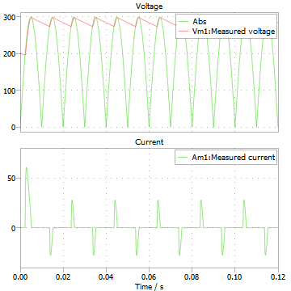

Gleichrichterkurven

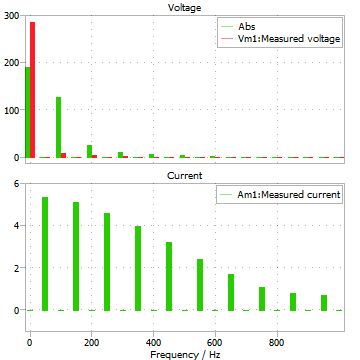

Rectifier spectrum

## 9.25 Harmonischer Verzerrungsgrad

**Tip**

Eine beliebige Funktion kann als Summe von Sinusfunktionen dargestellt werden.

$$f(x)=\sum_{n=-\infty}^\infty c_n e^{i2\pi \frac{n}{T}x}$$

Die Zerlegung eines periodischen Signals in *Fourier-Reihen* ergibt ein *Fundamental* und *Harmonische*.

Man hat den Effektivwert der Grundschwingung $\nu_1$ und die Effektivwerte der Oberschwingungen $\nu_i, i > 1$.

Den Klirrfaktor (total harmonic distortion THD) definiert man als

$$THD = 100 \cdot \frac{\sqrt{\sum_{h=2}^H{\nu^2_h}}}{\sqrt{\sum_{h=1}^H{\nu^2_h}}}$$

wobei $\nu_h$ der Effektivwert der Harmonischen vom Rang h ist.